# Question

It is easy to find the area of an ellipse. It is surprisingly difficult to find the perimeter (you need calculus).

The area of an ellipse is pretty intuitive because an ellipse is a stretched circle. The ellipse has two different radii, so instead of $A=\pi\cdot r\cdot r$ (for a circle), an ellipse’s area is found with the following equation.

$$A=\pi a b$$

where $a$ is the length of the semi-major axis and $b$ is the length of the semi-minor axis. Or, $a$ and $b$ are the largest and smallest radii of the ellipse.

If an ellipse is drawn with a string of length $13$ meters and two stakes placed $6.6$ meters apart. What is the area of the ellipse in square meters?

(The tolerance is $\pm 0.01 ~\mathrm{m}^2$.)

# Solution

We need to find $a$ and $b$. Remember the string’s length equals $2a$.

$$a~=~\frac{2a}{2}~=~\frac{13}{2}~=~6.5$$

The distance from the center to a focus, $c$, equals half the distance between the stakes.

$$c=\frac{6.6}{2}=3.3$$

We still need $b$, the shorter radius.

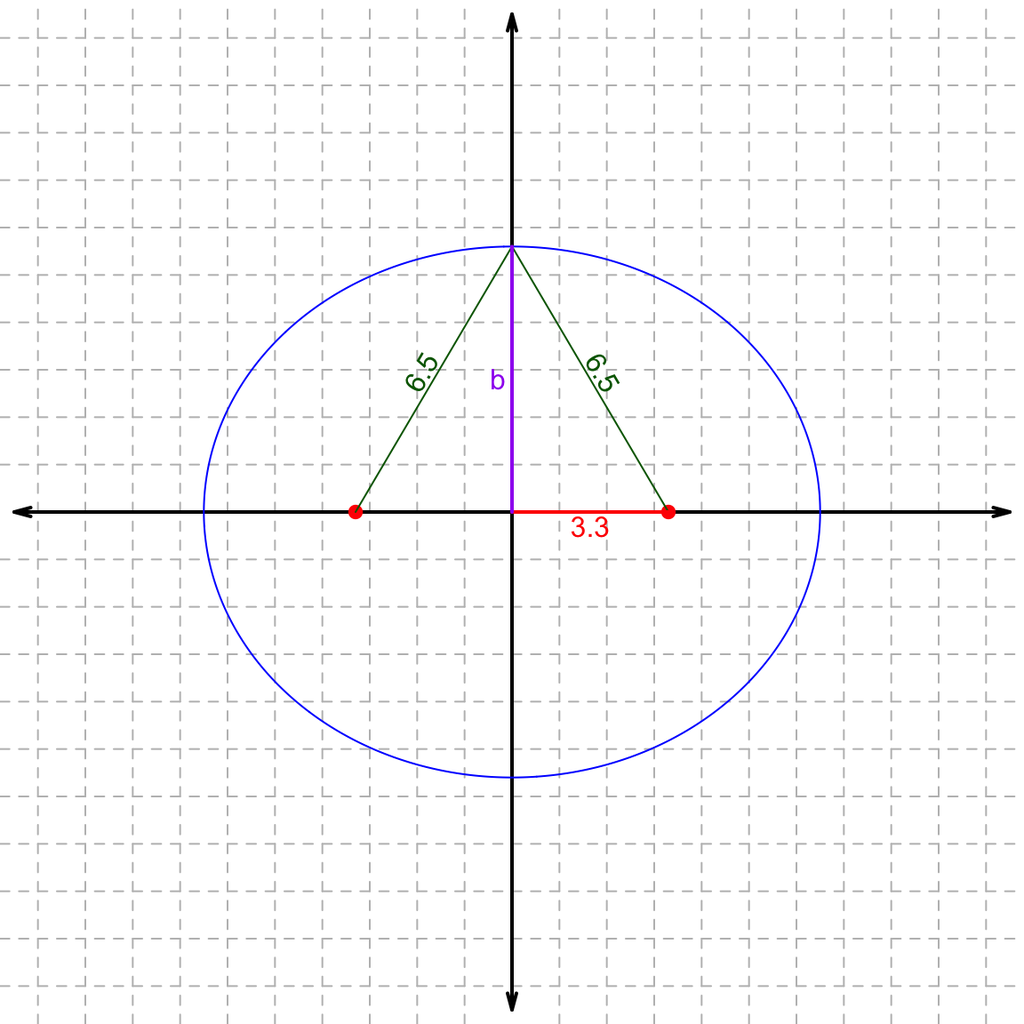

$$b=5.6$$

Find the area.

$$A ~=~ ab\pi ~=~
(6.5)(5.6)\pi$$

$$A \approx 114.35$$

The area is approximately 114.35 square meters.

# Meta-information

extype: num exsolution: 114.3539726 exname: area_of_ellipse extol: 0.01